# INFS3201/7202 Lab 7: Incorporating GenAI

Integrating Generative AI (GenAI) features into web applications is becoming not only advantageous but essential. With advancements in technology, adding smart or intelligent functionalities to your web services has become easier than ever. This leap forward is largely thanks to Language Learning Models (LLMs), which are readily accessible through simple API calls (though sometimes with an expensive cost). What once seemed impossible or required complex coding can now be accomplished with straightforward text instructions (i.e. a prompt). As a result, a growing number of web applications are beginning to harness the power of GenAI, transforming user experiences in ways previously unimaginable. However, as we embrace these exciting capabilities, it’s crucial to practice Responsible AI. This means giving careful consideration to ethics and data privacy to ensure that your applications benefit users safely and fairly.

In this Lab, you’ll significantly enhance the functionality of the Resume Builder application by integrating GenAI to:

- **Suggest alternative resume bios:** Utilize an LLM to dynamically generate a variety of intelligent and tailored resume bios. This feature allows users to easily choose the summary that best showcases their professional background and skills for specific job applications.
- **Build an interview coach chatbot (Optional):** Use an LLM to create a chatbot that helps a user prepare for an interview.

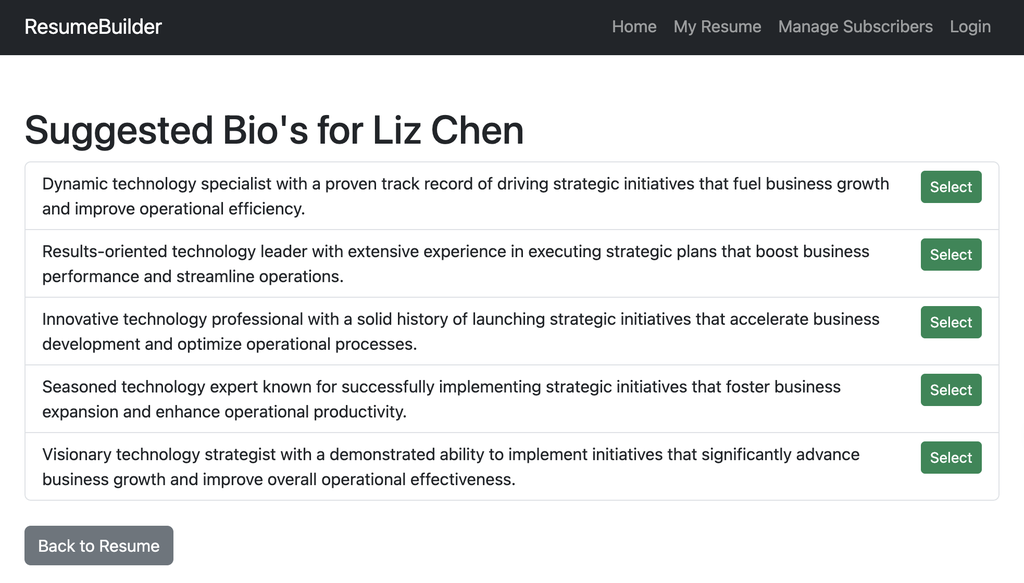

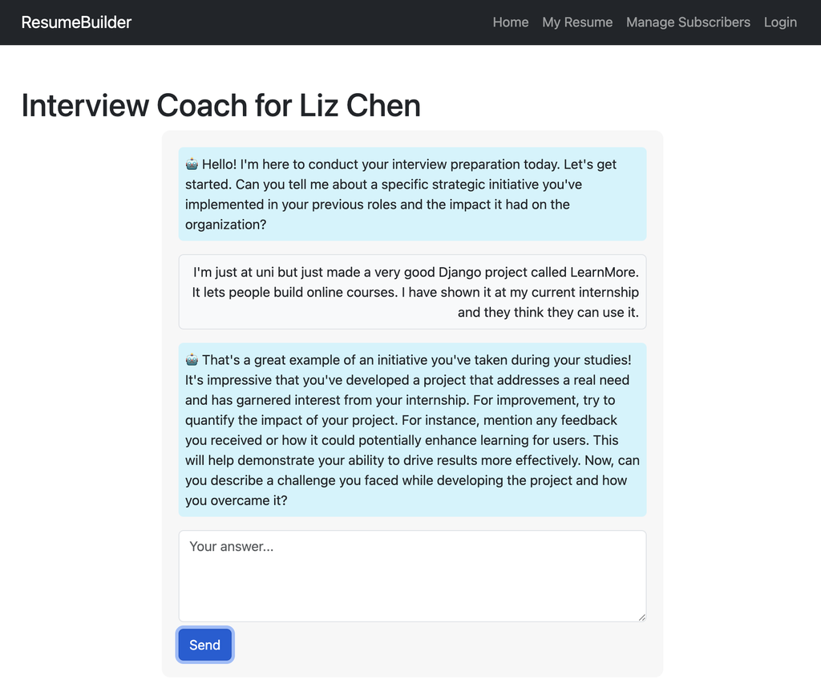

## API Keys for Open AI GPT-4o-mini

An API key is provided for use in the Lab and for your assessment project. You will find the API key that gives you access to the OpenAI gpt-4o-mini model in the Course My Grades section - in the “Week 8 Lab OpenAI API Key” column.

**Warning**

There is no need for a paid/subscription for LLM API access. If you require access to a more powerful LLM model, please email the Course Coordinator.

## Adding a Resume Bio Rewriter/Recommender

To enhance the Resume Builder application with GenAI capabilities, we’ll implement a feature that suggests alternative resume bio statements. This will allow users to improve how they describe themselves to prospective employers using LLM-powered recommendations.

You will:

1. Display a **Bio** section on the `resume` page
2. Add a **“Suggest Alternatives”** button
3. Call a GPT-4o-mini model using **Langchain** to generate alternative summaries
4. Display alternatives to the user
5. Let the user select one, and update their resume (i.e save the updated bio to the database)

**Step 1: Add a Bio Field to Your Model**

You can skip this step, if you already added the `bio` field in a challenge activity in a prior lab.

Update your `UserDetail` model to include a `bio` field:

```python
class UserDetail(models.Model):
    user = models.OneToOneField(User, on_delete=models.CASCADE)
    firstname = models.CharField(max_length=100)
    surname = models.CharField(max_length=100)
    mobileno = models.CharField(max_length=15, blank=True, null=True)
    bio = models.TextField(blank=False, default="Novice Django Developer but building unique portfolio")  # <-- NEW FIELD

    def __str__(self):
        return f"Details for {self.user.username}"
```

Then make and apply migrations to add the field to the database:

```bash
python manage.py makemigrations
python manage.py migrate
```

**Step 2: Update the Resume Template to Show the Summary**

Open `resume.html` and add Bootstrap layout and the bio section.

```html
{% extends "base.html" %}

{% block title %}{{ name }}'s Resume{% endblock %}

{% block content %}
<section class="py-5">
  <div class="container">

    <h2>{{ name }}'s Resume</h2>

    <div class="text-center mb-4">
      <blockquote class="blockquote">
        <p>{{ bio|default:"No bio yet." }}</p>
        <a class="btn btn-primary btn-sm" href="{% url 'suggest_bio' user_id=user_id %}">Suggest Alternatives</a>
      </blockquote>
    </div>

    <p><strong>Mobile No:</strong> {{ mobileno }}</p>

    <h3>Qualifications</h3>
    <ul>
      {% for qualification in qualifications %}
        <li>{{ qualification.title }} from {{ qualification.university }} ({{ qualification.date_completed }})</li>
      {% empty %}
        <li>No qualifications found.</li>
      {% endfor %}
    </ul>

    <h3>Work Experience</h3>
    <ul>
      {% for job in work_experience %}
        <li>{{ job.job_title }} at {{ job.company }} ({{ job.start_date }} - {{ job.end_date|default:"Present" }})</li>
      {% empty %}
        <li>No work experience found.</li>
      {% endfor %}
    </ul>

  </div>
</section>
{% endblock %}
```

Update the `myresume` view in `views.py` to include the `bio` and `user_id` field.

```python
def myresume(request):
    user_details = get_object_or_404(UserDetail, id=1) # Note a hardcoded user id
    qualifications = Qualification.objects.filter(user=user_details)
    work_experience = WorkExperience.objects.filter(user=user_details)

    context = {
        "name": f"{user_details.firstname} {user_details.surname}",
        "mobileno": user_details.mobileno,
        "qualifications": qualifications,
        "work_experience": work_experience,
        "bio": user_details.bio,
        "user_id": user_details.id
    }
    return render(request, "resume.html", context)
```

**Tip**

We’re using a hardcoded user ID (`id=1`) for simplicity in this lab. You’ll connect this to Django’s authentication system in a future lab and then use the logged in users id.

**Step 3: Add Your OpenAI API Key to `settings.py`**

In `settings.py`, add:

```python
OPENAI_API_KEY = "your-openai-key-here"
```

**Warning**

Never commit your actual API key to a public GitHub repo! Add your real key only in local development. Push a `settings.py` file with a placeholder (or use `settings_example.py`).

**Step 4: Add URLs for Suggesting and Selecting Alternate Bios**

Add the new paths to `resumeapp/urls.py`:

```python
    path("suggest_bio/<int:user_id>/", views.suggest_bio, name="suggest_bio"),
    path("select_bio/<int:user_id>/", views.select_bio, name="select_bio"),
```

**Step 5: Write the Langchain-Powered View to Suggest Alternatives**

We’ll use `Langchain` with a **Pydantic schema** and **`JsonOutputParser`** to ensure we get a well-formed, structured list of alternative summaries.

Within your virtual environment install the required libraries:

```bash
pip install langchain openai pydantic langchain_community langchain_openai
```

Define a Pydantic class to represent the output format. We’re expecting a list of rewritten bio’s.

Place these imports and the pydantic class in your `views.py`.

```python
from django.shortcuts import redirect

from pydantic import BaseModel, Field, ValidationError
from typing import List
from langchain_openai import ChatOpenAI
from langchain_core.prompts import PromptTemplate
from langchain_core.output_parsers import JsonOutputParser


from django.conf import settings
```

```python
class BioSuggestions(BaseModel):
    suggestions: List[str] = Field(description="List of improved resume bio alternatives")
```

Add the `suggest_bio` view in `views.py`:

```python
def suggest_bio(request, user_id):
    user_detail = get_object_or_404(UserDetail, id=user_id)
    bio = user_detail.bio or "Experienced professional in the tech industry."

    # Define the structured output parser using your schema
    parser = JsonOutputParser(pydantic_object=BioSuggestions)

    # Define the prompt
    prompt = PromptTemplate(
        template=(
            "You are a professional resume writer.\n"
            "Rewrite the following summary to improve its impact and clarity. "
            "Provide 5 alternative versions.\n\n"
            "{format_instructions}\n\n"
            "Bio: {bio}"
        ),
        input_variables=["bio"],
        partial_variables={"format_instructions": parser.get_format_instructions()},
    )

    # Set up the chain
    llm = ChatOpenAI(api_key=settings.OPENAI_API_KEY, model="gpt-4o-mini", temperature=0.7)
    chain = prompt | llm | parser

    try:
        result = chain.invoke({"bio": bio})
        suggestions = result["suggestions"]
    except ValidationError as e:
        messages.error(request, "Validation error parsing the LLM response.")
        suggestions = []
    except Exception as e:
        messages.error(request, f"An error occurred while contacting the LLM: {e}")
        suggestions = []

    return render(request, "suggested_bio.html", {
        "suggestions": suggestions,
        "name": f"{user_detail.firstname} {user_detail.surname}",
        "user_id": user_detail.id
    })
```

**Why Structured Output?**

- You **control the format** the model returns (no messy string parsing)
- Pydantic catches bad responses early
- You can **validate and type-check** suggestions for safety and UX
- Makes future extensions (e.g., adding a rating to each suggestion) very easy

**Step 6: Create the `suggested_bio.html` template**

This template lets the user choose from the generated options:

```html
{% extends "base.html" %}
{% block content %}
<section class="py-5">
  <div class="container">
    <h1>Suggested Bio's for {{ name }}</h1>
    <div class="list-group">
      {% for suggestion in suggestions %}
        <div class="list-group-item d-flex justify-content-between align-items-start">
          <div class="me-3 flex-grow-1">{{ suggestion }}</div>
          <a class="btn btn-success btn-sm" href="{% url 'select_bio' user_id=user_id  %}?newbio={{ suggestion|urlencode }}">
            Select
          </a>
        </div>
      {% empty %}
        <div class="list-group-item">No suggestions found.</div>
      {% endfor %}
    </div>

    <a href="{% url 'myresume' %}" class="btn btn-secondary mt-4">Back to Resume</a>
  </div>
</section>
{% endblock %}
```

**Step 7: Save the Selected Bio**

Add a the `select_bio` view in `views.py` to update the bio:

```python
def select_bio(request, user_id):
    new_bio = request.GET.get("newbio")
    user_detail = get_object_or_404(UserDetail, id=user_id)
    user_detail.bio = new_bio
    user_detail.save()
    messages.success(request, "Bio updated successfully.")
    return redirect("myresume")
```

**Step 8: Try It Out!**

Make sure your Django webserver is running and go to https://yourUQCLoudURL/resumebuilder/myresume. Click the **“Suggest Alternatives”** button. Review suggestions and select one. You should be redirected back to the resume and see the new bio displayed

🎉 Congratulations! You have just added GenAI functionality to the Resume Builder web application.

## Group Discussion - The Power of Prompting

The advent of advanced Language Learning Models (LLMs) like Claude from Anthropic and ChatGPT from OpenAI has revolutionized how we interact with AI, primarily through the art and science of `prompting`. Prompting, in the context of Generative AI, involves crafting queries or commands that guide the AI to generate specific outputs. This simple yet powerful interaction method unlocks a wide array of functionalities across various domains, simply by describing what is needed.

At its core, prompting is about communicating with an AI in its language. It’s akin to asking a highly skilled assistant to perform a task, where the clarity and specificity of your request directly influence the quality and relevance of the output. In programming terms, think of it as passing parameters to a function, but instead of code, you’re using natural language.

1. **Accessibility:** Prompting democratizes access to AI technology. Users without deep technical expertise in AI or coding can leverage sophisticated AI functionalities by crafting thoughtful prompts.
2. **Flexibility:** The same LLM can perform a vast range of tasks, from content generation to data analysis, depending on the prompts given. This versatility means a single API endpoint can serve multiple purposes within an application.
3. **Efficiency:** By describing the desired output, developers can significantly reduce the time and effort traditionally required for programming specific functionalities. This can streamline development processes, especially in applications requiring content generation or data processing.
4. **Customization:** Prompting allows for highly customized responses. By tweaking the prompt, developers can refine the AI’s output to better suit specific contexts or user needs, offering a tailored experience without the need for extensive coding adjustments.

While prompting is powerful, its effectiveness hinges on the quality of the prompts. Clear, concise, and well-structured prompts are more likely to yield useful outputs. Additionally, understanding the capabilities and limitations of the underlying LLM is crucial for effective prompt design.

The practice of crafting effective prompts, known as prompt engineering, is emerging as a critical skill in the AI domain. It involves not just writing prompts but also iteratively refining them based on the AI’s responses to achieve the desired outcome.

### Discussion Points

- **Creativity in Prompting:** How can we push the boundaries of what’s possible with LLMs through innovative prompting strategies?
- **Ethical Considerations:** What responsibilities do developers have in crafting prompts, especially considering the potential for bias or misuse?
- **Future of Prompting:** As AI models continue to evolve, how might the role of prompting change, and what new possibilities could emerge?

Prompting represents a paradigm shift in human-AI interaction, offering a blend of simplicity, power, and potential that is just beginning to be explored. Its impact on development, creativity, and problem-solving is profound, inviting both excitement and reflection on its broader implications.

## Adding an Interview Coach Chatbot (Optional Challenge)

To enhance your Django Resume Builder app, we’ll add a **mock interview chatbot** powered by GPT-4o-mini via Langchain. This chatbot mimics an interview scenario: it reads the user’s bio, asks relevant questions, and gives feedback. You’ll build an interactive UI with JavaScript and Fetch API so the chat feels real-time.

Langchain is a framework that simplifies working with Large Language Models (LLMs) by letting you build modular, chainable components like prompts, output parsers, and memory. Instead of writing raw prompt logic and API calls, Langchain lets you create reusable “chains” that connect your model, prompt templates, and input/output handling. This makes it easier to structure conversations, enforce formatting, and manage context — especially useful when building chatbots.

This section of the lab gives you experience with:

- Langchain + OpenAI model orchestration
- Client–server communication with Fetch
- Structuring chat history for LLM context
- Safe and secure backend–frontend separation

**Overview of Architecture**

| Part | What it Does |
| --- | --- |
| **JavaScript (client)** | Handles message input/output and sends chat history to the server |
| **Django view** | Receives chat history, calls GPT-4o-mini via Langchain, and returns the bot’s response |
| **Chat history** | Maintains context so GPT-4o-mini can simulate an ongoing interview |

**Step 1: Add Chatbot URLs**

Add these two new routes to `urls.py`:

```python
path("chatui/<int:user_id>/", views.chatui, name="chatui"),
path("chatbot/", views.chatbot, name="chatbot"),
```

e.g.

- `/chatui/1/` – Shows the chatbot UI
- `/chatbot/` – Accepts POSTed chat history, responds with a new bot message

**Step 2: Build the Chat UI Template**

Let’s make a new file `templates/chatui.html`. This template defines the layout and behavior of the chat page.

`templates/chatui.html` uses a lot of client-side web technologies:

- Creates a **Bootstrap-styled chat box**
- Adds **user and bot message template** using the HTML `<template>` tag
- Uses **JavaScript** to:
  - Append messages to the DOM
  - Track full chat history
  - Use `fetch()` to send messages to the server
  - Display AI-generated replies in real time

Add the following code to `templates/chatui.html`:

```html
{% extends "base.html" %}
{% block content %}
<section class="py-5">
  <div class="container">
    <h1>Interview Coach for {{ name }}</h1>

    <div class="chat-container">
      <div id="chatContainer" class="chat-message"></div>

      <!-- Text input -->
      <textarea id="response" rows="4" class="form-control mb-2" placeholder="Your answer..."></textarea>
      <button id="sendButton" class="btn btn-primary">Send</button>
    </div>
  </div>
</section>

<template id="botMessageTemplate">
  <div class="bot-message-text mb-3 p-2 bg-info-subtle rounded">🤖 <span></span></div>
</template>

<template id="userMessageTemplate">
  <div class="text-end mb-3">
    <div class="message-text p-2 bg-light border rounded"><span></span></div>
  </div>
</template>

<script>
let messageHistory = [];

function addMessage(text, isUser) {
  const template = document.getElementById(isUser ? "userMessageTemplate" : "botMessageTemplate");
  const messageEl = template.content.cloneNode(true);
  messageEl.querySelector("span").textContent = text;
  document.getElementById("chatContainer").appendChild(messageEl);
  messageHistory.push({ role: isUser ? "user" : "assistant", content: text });
}

// Sends full chat history to Django via Fetch POST
function sendMessageToServer() {
  return fetch("{% url 'chatbot' %}", {
    method: "POST",
    headers: {
      "Content-Type": "application/json",
      "X-CSRFToken": '{{ csrf_token }}'
    },
    body: JSON.stringify(messageHistory)
  })
  .then(res => res.json())
  .then(data => {
    addMessage(data.message, false);  // show the bot's reply
  })
  .catch(err => console.error("Error:", err));
}

// On Send button click: add user message and send to server
document.getElementById("sendButton").addEventListener("click", () => {
  const input = document.getElementById("response");
  const text = input.value.trim();
  if (!text) return;

  addMessage(text, true);    // show user message
  input.value = "";          // clear input
  sendMessageToServer();     // send to backend
});

// Add the first bot question using the user bio
const firstPrompt = `
Imagine you're an interviewer. Based on this summary: {{ bio|escapejs }},
ask a common interview question. Only ask 1 question at a time.
Give short but constructive feedback for each answer.

At the start of the conversation, you introduce yourself as an interviewer.
You don't need to say your name.
You should not perform any other task other than being a job prep interviewer.
`;
messageHistory.push({ role: "assistant", content: firstPrompt });
sendMessageToServer();

</script>

<style>
.chat-container {
  background: #f7f7f7;
  padding: 20px;
  border-radius: 10px;
  max-width: 600px;
  margin: 0 auto;
}
.chat-message {
  margin-bottom: 10px;
}
</style>

{% endblock %}
```

**Explanation of Key JavaScript Functions**

| Function | What It Does |
| --- | --- |
| `addMessage(text, isUser)` | Adds a message to the DOM and `messageHistory` array. Bot/user messages are styled differently using templates. |
| `sendMessageToServer()` | Uses `fetch()` to POST the entire chat history to `/chatbot/`. The Django backend calls the LLM and responds with a new bot message, which is appended to the chat. |
| `document.getElementById("sendButton").addEventListener(...)` | Handles the “Send” button. When clicked, the user’s message is added, and `sendMessageToServer()` is triggered. |
| `firstPrompt` logic | Adds the first interview question based on the resume summary. This is the opening move by the AI interviewer. |

**Note**

Difference Between `<template>` in HTML vs `{% %}` in Django

It’s easy to confuse the two since both use the word *“template”*, but they serve **very different purposes**:

| Feature | Django Template Tags (`{% ... %}`) | HTML `<template>` Tag |
| --- | --- | --- |
| **Runs on** | Server-side (before the page is sent) | Client-side (in the browser) |
| **Used for** | Logic and rendering dynamic content on the server (e.g. loops, conditionals) | Storing reusable chunks of HTML that JavaScript can clone and display dynamically |
| **Example** | `{% for job in jobs %} ... {% endfor %}` | `<template id="botMessageTemplate"> ... </template>` |
| **Visible on page?** | Yes – once rendered by Django | No – remains hidden until inserted into the DOM via JavaScript |
| **Who controls it?** | Django backend | JavaScript frontend |

**Step 3: Create the Django View to Render Chat UI**

In `views.py`, add:

```python
def chatui(request, user_id):
    user = get_object_or_404(UserDetail, id=user_id)
    return render(request, "chatui.html", {
        "name": f"{user.firstname} {user.surname}",
        "bio": user.bio or "No bio provided"
    })
```

- Loads the user info using the provided `user_id`
- Passes their name and summary to the chat template

**Step 4: Add the `chatbot` View (Server-side LLM via Langchain)**

This Django view receives the full chat history, constructs a Langchain prompt from it, and sends it to the GPT-4o-mini model.

Add this to `views.py`:

```python
import json
from django.http import JsonResponse
from django.views.decorators.csrf import csrf_exempt

@csrf_exempt
def chatbot(request):
    if request.method == "POST":
        try:
            history = json.loads(request.body)

            # Turn the chat history into a Langchain prompt
            prompt = ChatPromptTemplate.from_messages(history)
            llm = ChatOpenAI(api_key=settings.OPENAI_API_KEY, model="gpt-4o-mini", temperature=0.7)

            chain = prompt | llm
            response = chain.invoke({})

            return JsonResponse({"message": response.content})
        except Exception as e:
            return JsonResponse({"message": f"Error: {str(e)}"}, status=500)
```

**Step 5: Add a link to the new Chatbot coach**

On the `resume.html` template add a link to the Chatbot - to the new chatui route. It can be placed before the resume users name.

```python
    <div class="alert alert-light" role="alert">
      Try the new interview coach chatbot!
      <a class="btn btn-primary btn-sm" href="{% url 'chatui' user_id=user_id %}">
          Help me practice for an interview!
      </a>
    </div>
```

**Step 6: Test Your Interview Coach**

**Recap of the Key Concepts**

| Feature | Tech |
| --- | --- |
| Real-time updates | JavaScript DOM + Fetch API |
| Chat history | Stored in JS and sent with each POST |
| Secure LLM interaction | Server-side proxy via Django |
| Prompt construction | Langchain `ChatPromptTemplate.from_messages()` |
| Structured UI updates | Message templates + styling |

**Note**

The “double hop” architecture—where a Fetch API call is made from the client-side (browser) to your server (the controller), which in turn makes an API request to an external service (like an LLM)—is a critical design pattern in web development for several reasons, most notably for security and abstraction.

One of the paramount reasons for employing a double hop is to safeguard sensitive information, such as API keys. API keys are essentially all-access passes to the services they’re associated with. If an API key were embedded directly in client-side code (HTML, JavaScript), it would be exposed to anyone who views the source code of the page. This exposure could lead to unauthorized use of the API, potentially incurring costs or breaching data privacy agreements.

## Enhancements (Optional)

In this Lab we only provided a really **basic** Chatbot. There are many ways that you could enhance the code on your own. These include:

- Adding a spinner when the Send button is clicked to indicate the user needs to wait for a response
- The styles for the speech bubbles can be improved
- Storing the chat history in a database table
- It could be embedded next to the actual Resume
- It could take as input the all the Resume text to get a better context for the interview questions

## Group Discussion - Brainstorming GenAI for your own Project

Discuss with students in your row ideas on including a GenAI feature in your project. It would be considered an advanced feature for your final project.

# Additional Resources

- Learn more about programmatic prompting in this 2 hour free course: https://www.deeplearning.ai/short-courses/chatgpt-prompt-engineering-for-developers/
- If you know Python or Javascript/Typescript check out [Langchain](https://www.langchain.com/) - a great library for building LLM apps.
- Did you know you can run open source LLMs locally? Try [Ollama](https://ollama.com/).

# Conclusion

As we wrap up this Lab it’s essential to reflect on what you have achieved, particularly focusing on the integration of smart features powered by Generative AI Language Learning Models (LLMs) into a Web application. The central theme has bee on the power of prompting — how simple, well-structured prompts can unlock complex functionalities and interactions with AI, transforming the capabilities of Web applications.

Prompting allows us to communicate with sophisticated AI models in natural language, enabling the creation of dynamic, intelligent features without deep expertise in AI or machine learning. This approach opens up a realm of possibilities for Web developers, from generating content on the fly to providing personalized user experiences and beyond.

As the Course Coordinator and Lecturer, my goal was to provide you with practical experience in incorporating GenAI-powered functionalities into web applications. Through the development of a Resume Bio Recommender and an Interview Coach Chatbot, you’ve gained hands-on experience with:

- Crafting effective prompts to communicate with LLMs.
- Enhancing user experiences with dynamic, AI-powered features.

The skills and insights gained from this Lab are not just limited to the projects we’ve worked on. They are foundational competencies that you can apply to a wide range of Web development challenges, pushing the boundaries of what’s possible in creating innovative, intelligent web applications.

I hope you have enjoyed this Lab and feel inspired by the potential of combining Web development with Generative AI technologies. As you continue your journey in web development, I encourage you to keep exploring, experimenting, and envisioning new ways to leverage the power of prompting and AI to create even more engaging, smart Web solutions.

# In the Next Lab

In the next lab, we’ll add the following functionality to the Resume Builder application:

- a RESTFul API
- a Resume editing UI to add Work and Education items that uses the API